# Tech 3. Specification Curves

## Load Data

```r
cri <- read.csv(file = here::here("data/cri.csv"), header = TRUE)
cri <- subset(cri, u_teamid != 0)
cri_str <- read.csv(file = here::here("data/cri_str.csv"), header = TRUE)
cri_str <- subset(cri_str, u_teamid!=0)
cri_team <- read.csv(file = here::here("data/cri_team.csv"), header = TRUE)
cri_team <- subset(cri_team, u_teamid!=0)
```

## Model-Level Effect Specifications

### Main Plot

Setup

```r
# create identifier of neg, ns, pos
crispectest <- crispectest %>%
  mutate(sig_group = as.factor(ifelse(est < 0 & ub > 0, NA, ifelse(est > 0 & lb < 0, NA, ifelse(est < 0 & ub < 0, 1, ifelse(est > 0 & lb > 0, 3, 2))))),
         est_sig = ifelse(!is.na(sig_group), est, NA),
         est_ns = ifelse(is.na(sig_group), est, NA),
         sig_group2 = as.factor(ifelse(is.na(sig_group), 2, sig_group)))

#compress values for better visualization
# 0-0.05 = 0-1
# 0.05-0.505 = 1-2

crispectest <- crispectest %>%
  mutate(est_ns_scl = abs(est_ns),
         est_ns_scl = ifelse(est_ns_scl > 0 & est_ns_scl <= 0.05, est_ns_scl/0.05, ifelse(est_ns_scl > 0.05 & est_ns_scl <=0.505, ((est_ns_scl - 0.05)/0.505)+1, est_ns_scl+1.505)),
         est_ns_scl = ifelse(est_ns > 0, est_ns_scl, -1*est_ns_scl),
         est_sig_scl = abs(est_sig),
         est_sig_scl = ifelse(est_sig_scl > 0 & est_sig_scl <= 0.05, est_sig_scl/0.05, ifelse(est_sig_scl > 0.05 & est_sig_scl <=0.505, ((est_sig_scl - 0.05)/0.505)+1, est_sig_scl+1.505)),
         est_sig_scl = ifelse(est_sig > 0, est_sig_scl, -1*est_sig_scl))
```

Generate weighted percentage of each effect

```r
sig_neg <- 100*round(sum(crispectest$inv_weight[crispectest$sig_group2 == 1])/sum(crispectest$inv_weight),3)

sig_pos <- 100*round(sum(crispectest$inv_weight[crispectest$sig_group2 == 3])/sum(crispectest$inv_weight),3)

ns <- 100*round(sum(crispectest$inv_weight[crispectest$sig_group2 == 2])/sum(crispectest$inv_weight),3)
```

Generate and save Fig 1

```r
# for plotting a circle
dat = data.frame(x=runif(1), y=runif(1))

agg_png(filename = here::here("results/Fig1.png"), width = 800, height = 500, res = 144)
ggplot(crispectest) +
  #geom_errorbar(aes(ymin = lb, ymax = ub), color = "thistle1") +
  geom_point(aes(x = count, y = est_ns_scl), color = "grey55", shape = "|", size = 2, show.legend =F) +
  geom_point(aes(x = count, y = est_sig_scl, color = sig_group), shape = "|", size = 3) +
  scale_color_manual(values = c("#E6AB02","NA", "#7570B3"), labels = c("Negative","Not sig.","Positive"," ")) +
  #geom_vline(xintercept = 1214, color = "grey", linetype = "dashed") +
  #geom_vline(xintercept = 52, color = "grey", linetype = "dashed") +
  #ylim(-1.8, 1.8) +
  annotate(geom = "text", x = 340, y = 1.45, label = "NEGATIVE (95% CI)", color = "#E6AB02", fontface = "bold", size = 3) +
  annotate(geom = "text", x = 940, y = 1.45, label = "POSITIVE (95% CI)", color = "#7570B3", fontface = "bold", size = 3) +
  annotate(geom = "text", x = 640, y = 1.45, label = "NOT STAT.\nSIGNIFICANT", fontface = "bold", color = "grey55", size = 3) +
  #annotate(geom = "text", x = 680, y = -1.5, label = "grey indicates not sig.\ndifferent from zero", color = "grey55", size = 3) +
  geom_vline(xintercept = -30) +
  annotate(geom = "segment", x = -35, xend = -25, y = -1.1, yend = -1.1, color = "white", size = 2) +
  annotate(geom = "segment", x = -35, xend = -25, y = 1.1, yend = 1.1, color = "white", size = 2) +
  annotate(geom = "segment", x = -38, xend = -22, y = 1.12, yend = 1.18, color = "black", size = 0.5) +
  annotate(geom = "segment", x = -38, xend = -22, y = -1.18, yend = -1.12, color = "black", size = 0.5) +
  labs(color = "Effect at 95% CI", x = "Models Ordered by AME", y = "Average Marginal Effect (AME)") +
  geom_point(aes(x=340, y=-2), data=dat, size=18, shape=1, color="#E6AB02") +
  geom_point(aes(x=640, y=-2), data=dat, size=26, shape=1, color="grey55") +
  geom_point(aes(x=940, y=-2), data=dat, size=14, shape=1, color="#7570B3") +
  annotate("text", x=340, y=-2, label = paste(sig_neg), color="#E6AB02", fontface = "bold") +
  annotate("text", x=640, y=-2, label = paste(ns), color="grey55", fontface = "bold") +
  annotate("text", x=940, y=-2, label = paste(sig_pos), color="#7570B3", fontface = "bold") +
  annotate("text", x=640, y=-1.1, label = "Weighted % of Distribution:", color="grey20", size = 2.5, fontface = 3) +
  annotate("text", x=640, y=0.5, label = "Point Estimates:", color="grey20", size = 2.5, fontface = 3) +
  scale_y_continuous(labels = c("-0.50","-0.05","0.00","0.05","0.50"), breaks = c(-1.75, -1, 0, 1, 1.75), limits = c(-2.6,1.8)) +
  coord_cartesian(xlim = c(-15,1255), clip = "off") +
  scale_x_continuous(expand = c(0,15)) +
  theme_classic() +
  guides(color = guide_legend(override.aes = list(size=7, color=c("#E6AB02","grey55", "#7570B3","NA")))) +
  theme(
    legend.key.size = unit(2,"line"),
    legend.position = "none",
    #axis.title.x = element_blank()
    axis.line.y = element_blank(),
    )
dev.off()
```

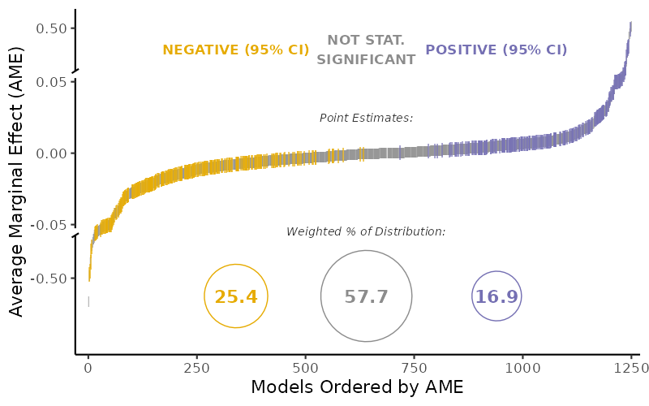

```r
knitr::include_graphics(here::here("results/Fig1.png"))
```

### Supplementary Plots

#### Fig 1_supplementary.

This figure combines many spec curves. Two big ones with researcher characteristics, and several small ones with the sub-domains of specifications.

First two are ordered by effect size, the other by confidence interval minimum/maximum relative to the hypothesis.

#### Panel A. By Effect Size

```r
g1 <- ggplot(crispectest) +
  #geom_errorbar(aes(ymin = lb, ymax = ub), color = "thistle1") +
  geom_point(aes(x = count, y = est_ns), color = "grey55", shape = "|", size = 2, show.legend =F) +
  geom_point(aes(x = count, y = est_sig, color = sig_group), shape = "|", size = 3) +
  scale_color_manual(values = c("#E6AB02","grey55", "#7570B3"), labels = c("Negative","Not sig.","Positive"," ")) +
  ylim(-0.21, 0.21) +
  labs(color = "Effect at 95%CI", x = "Model", y = " \n \nStandardized\nEffect Size") +
  theme_classic() +
  guides(color = guide_legend(override.aes = list(size=7, color=c("#E6AB02","grey55", "#7570B3","NA")))) +
  theme(
    legend.key.size = unit(2,"line"),
    legend.position = "none",
    axis.title.x = element_blank())

# make an adjusted version for the smaller plots
g1a <- ggplot(crispectest) +
  #geom_errorbar(aes(ymin = lb, ymax = ub), color = "thistle1") +
  geom_point(aes(x = count, y = est_ns), color = "grey55", shape = "|", size = 3, show.legend =F) +
  geom_point(aes(x = count, y = est_sig, color = sig_group), shape = "|", size = 4) +
  scale_color_manual(values = c("#E6AB02","grey55", "#7570B3"), labels = c("Negative","Not sig.","Positive"," ")) +
  ylim(-0.21, 0.21) +
  labs(color = "Effect at 95%CI", x = "by Standardized Effect Size", y = " \n \n \n ") +
  theme_classic() +
  guides(color = guide_legend(override.aes = list(size=7, color=c("#E6AB02","grey55", "#7570B3","NA")))) +
  theme(
    legend.position = "none",
    axis.text.x = element_blank())
```

##### Panel B. By Confidence Interval

```r
# create identifier of neg, ns, pos
crispectest <- crispectest %>%
  mutate(ci = ifelse(sig_group2 == 1, ub, ifelse(sig_group2 == 3, lb, ifelse(est <= 0 & sig_group2 == 2, ub, ifelse(est > 0 & sig_group2 == 2, lb, NA)))),
         ub_order = ifelse(est <= 0 & sig_group2 == 1, 0, ifelse(est <= 0 & sig_group2==2, 1, ifelse(est > 0 & sig_group2==2, 2, ifelse(est > 0 & sig_group2 == 3, 3, NA)))),
         )

# order rows to make counter

crispectest <- crispectest[order(crispectest$ub_order, crispectest$ci),]
crispectest$count2 <- 1:nrow(crispectest)

# make an estimate where error bars show only for significant at 95% results
crispectest <- crispectest %>%
  mutate(est2 = ifelse(sig_group2 == 2, 0, est))

g2 <-
  ggplot(crispectest) +
  geom_errorbar(aes(x = count2, ymin = lb, ymax = ub), color = "grey55") +
  geom_point(aes(x = count2, y = est, color = sig_group2), size = 1) +
  scale_color_manual(values = c("#E6AB02","grey55", "#7570B3"), labels = c("Negative","Not sig.","Positive")) +
  coord_cartesian(ylim = c(-0.21,0.21)) +
  labs(color = "Effect\nat 95%CI", x = "Model", y = "Effect Range", size = 2) +
  annotate("text", x = 450, y = 0.13,label = "Effects < 0\nordered by\nupper bound", size = 2.5, color = "grey10") +
  annotate("text", x = 900, y = -0.13,label = "Effects > 0\nordered by\nlower bound", size = 2.5, color = "grey10") +
  geom_segment(aes(x = 600, y = 0.08, xend = 350, yend = 0.08), arrow = arrow(length = unit(0.2, "cm"), type = "closed"), color = "grey10") +
  geom_vline(xintercept = 688) +
  geom_segment(aes(x = 776, y = -0.08, xend = 1000, yend = -0.08), arrow = arrow(length = unit(0.2, "cm"), type = "closed"), color = "grey10") +
  geom_vline(xintercept = 688) +
  theme_classic() +
  theme(
    axis.title.x = element_blank()
  )

# make an adjusted version for the smaller plots
g2a <- ggplot(crispectest) +
  geom_errorbar(aes(x = count2, ymin = lb, ymax = ub), color = "grey55") +
  geom_point(aes(x = count2, y = est, color = sig_group2), size = 1) +
  scale_color_manual(values = c("#E6AB02","grey55", "#7570B3"), labels = c("Negative","Not sig.","Positive")) +
  coord_cartesian(ylim = c(-0.21,0.21)) +
  labs(color = "Effect\nat 95%CI", x = "by Confidence Interval Minimum", size = 2) +
  geom_vline(xintercept = 688) +
  theme_classic() +
  theme(
    legend.position = "none",
    axis.text.x = element_blank(),
    axis.title.y = element_blank(),
    axis.text.y = element_blank()
  )
```

Heatmap Concept

We create a ‘rolling average’ of researcher characteristics across rows ordered by effect size. This is visually pleasing and helps identify any patterns (one tick per model for so many models is really hard visually with a continuous color scale).

```r
# create rolling average for effect ordering
crispectest <- crispectest[order(crispectest$count),]

# mean replacement, then rolling average, replace ends of rolling average w/ reg scores
crispectest <- crispectest %>%
  mutate(belief_ipredm = scale(ifelse(is.na(belief_ipred), mean(belief_ipred, na.rm=T), belief_ipred)),
         pro_immigrantm = scale(ifelse(is.na(pro_immigrant), mean(pro_immigrant, na.rm=T), pro_immigrant)),
         topic_ipredm = scale(ifelse(is.na(topic_ipred), mean(topic_ipred, na.rm=T), topic_ipred)),
         stats_ipredm = scale(ifelse(is.na(stats_ipred), mean(stats_ipred, na.rm=T), stats_ipred)),
         total_scorem = scale(ifelse(is.na(total_score), mean(total_score, na.rm=T), total_score)),
         belief_roll = zoo::rollmean(belief_ipredm, k = 30, fill = NA),
         pro_roll = zoo::rollmean(pro_immigrantm, k = 30, fill = NA),
         topic_roll = zoo::rollmean(topic_ipredm, k = 30, fill = NA),
         stats_roll = zoo::rollmean(stats_ipredm, k = 30, fill = NA),
         total_roll = zoo::rollmean(total_scorem, k = 30, fill = NA),
         belief_roll = ifelse(is.na(belief_roll), mean(belief_ipredm[count>1230,]), ifelse(is.na(belief_roll) & count < 30, mean(belief_ipredm[count<40,]), belief_roll)),
         pro_roll = ifelse(is.na(pro_roll) & count > 1230, mean(pro_immigrantm[count>1230,]), ifelse(is.na(pro_roll) & count < 30, mean(pro_immigrantm[count < 40,]), pro_roll)),
         topic_roll = ifelse(is.na(topic_roll) & count > 1230, mean(topic_ipredm[count>1230,]), ifelse(is.na(topic_roll) & count < 30, mean(topic_ipredm[count<30,]), topic_roll)),
         stats_roll = ifelse(is.na(stats_roll) & count > 1230, mean(stats_ipredm[count>1215,]), ifelse(is.na(stats_roll) & count < 30, mean(stats_ipredm[count<30,]), stats_roll)),
         total_roll = ifelse(is.na(total_roll) & count > 1230, mean(total_scorem[count>1230,]), ifelse(is.na(total_roll) & count < 30, mean(total_scorem[count<30,]), total_roll))
                              )

# create rolling average for effect CI order
crispectest <- crispectest[order(crispectest$count2),]

# mean replacement, then rolling average then replace tails w/ mean
crispectest <- crispectest %>%
  mutate(belief_roll2 = zoo::rollmean(belief_ipredm, k = 30, fill = NA),
         pro_roll2 = zoo::rollmean(pro_immigrantm, k = 30, fill = NA),
         topic_roll2 = zoo::rollmean(topic_ipredm, k = 30, fill = NA),
         stats_roll2 = zoo::rollmean(stats_ipredm, k = 30, fill = NA),
         total_roll2 = zoo::rollmean(total_scorem, k = 30, fill = NA),
         belief_roll2 = ifelse(is.na(belief_roll2), mean(belief_ipredm[count2>1230,]), ifelse(is.na(belief_roll2) & count2 < 30, mean(belief_ipredm[count2<30,]), belief_roll2)),
         pro_roll2 = ifelse(is.na(pro_roll2) & count2 > 1230, mean(pro_immigrantm[count2>1230,]), ifelse(is.na(pro_roll2) & count2 < 30, mean(pro_immigrantm[count2 < 30,]), pro_roll2)),
         topic_roll2 = ifelse(is.na(topic_roll2) & count2 > 1230, mean(topic_ipredm[count2>1230,]), ifelse(is.na(topic_roll2) & count2 < 30, mean(topic_ipredm[count2<30,]), topic_roll2)),
         stats_roll2 = ifelse(is.na(stats_roll2) & count2 > 1230, mean(stats_ipredm[count2>1215,]), ifelse(is.na(stats_roll2) & count2 < 30, mean(stats_ipredm[count2<30,]), stats_roll2)),
         total_roll2 = ifelse(is.na(total_roll2) & count2 > 1230, mean(total_scorem[count2>1230,]), ifelse(is.na(total_roll2) & count2 < 30, mean(total_scorem[count2<30,]), total_roll2))
                              )
labs_y <- c("Model Score","Stats-Skill","Topic\nKnowledge","Pro Immigrant","Belief Hyp. True")

g3 <- ggplot(crispectest) +
  geom_tile(aes(x = count, y = 5, fill = belief_roll), height = 0.5, width = 0.25) +
  geom_tile(aes(x = count, y = 4, fill = pro_roll), height = 0.5, width = 0.25) +
  geom_tile(aes(x = count, y = 3, fill = topic_roll), height = 0.5, width = 0.25) +
  geom_tile(aes(x = count, y = 2, fill = stats_roll), height = 0.5, width = 0.25) +
  geom_tile(aes(x = count, y = 1, fill = total_roll), height = 0.5, width = 0.25) +
  scale_y_continuous(breaks = c(1,2,3,4,5), labels=labs_y) +
    theme_classic() +
  xlab("Models ordered by Effect Size") +
  theme(
    legend.position = "none",
    axis.title.y = element_blank()
  )
labs_y2 <- c("Model","l","e","t","e")

g4 <- ggplot(crispectest) +
  geom_tile(aes(x = count2, y = 5, fill = belief_roll2), height = 0.5, width = 0.25) +
  geom_tile(aes(x = count2, y = 4, fill = pro_roll2), height = 0.5, width = 0.25) +
  geom_tile(aes(x = count2, y = 3, fill = topic_roll2), height = 0.5, width = 0.25) +
  geom_tile(aes(x = count2, y = 2, fill = stats_roll2), height = 0.5, width = 0.25) +
  geom_tile(aes(x = count2, y = 1, fill = total_roll2), height = 0.5, width = 0.25) +
  labs(fill = "Score") +
  scale_y_continuous(breaks = c(1,2,3,4,5), labels=labs_y2) +
  xlab("Models ordered by Minimum Confidence Boundary (95%CI)") +
    theme_classic() +
  theme(
    plot.margin=unit(c(0.1,0.9,0.1,0.3),"cm"),
    axis.text.y = element_text(color = "NA"),
    axis.title.y = element_blank(),
    legend.text = element_text(size = 6),
    legend.title = element_text(size = 8)
  )
```

#### Fig S6.

```r
agg_png(filename = here::here("results/FigS6.png"), res = 144, height = 900, width = 1700)
ggarrange(g1,g2,g3,g4, labels = c("A ","B ","C ","D "))
dev.off()
```

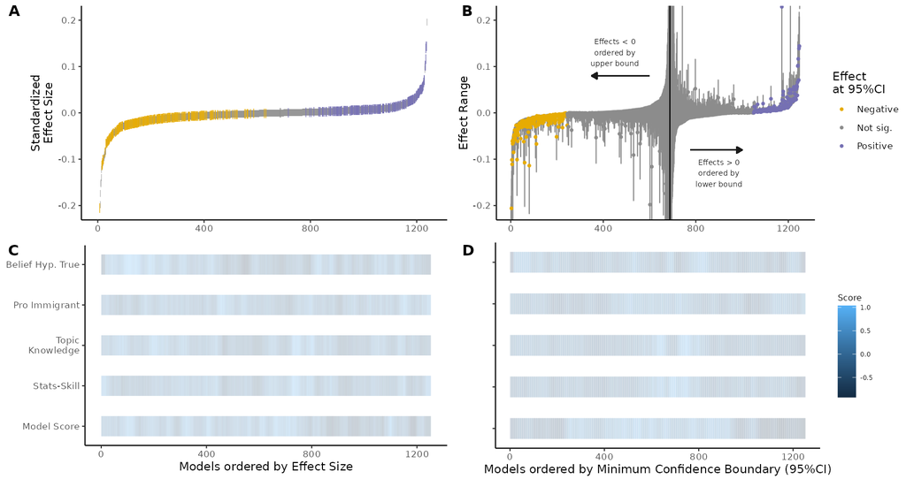

```r
knitr::include_graphics(here::here("results/FigS6.png"))
```

#### Fig 1. Sub-plots

We include two smaller versions of the spec-curves with four sub-domains of specifications below. This time without a rolling average.

First we recode our variables of interest into 1/0s for plotting:

```r
crispectest <- crispectest %>%
  mutate(DV_Jobs = ifelse(is.na(Jobs), 0, 1), # Measurement
         DV_Unemp = ifelse(is.na(Unemp), 0, 1),
         DV_IncDiff = ifelse(is.na(IncDiff), 0, 1),
         DV_OldAge = ifelse(is.na(OldAge), 0, 1),
         DV_House = ifelse(is.na(House), 0, 1),
         DV_Health = ifelse(is.na(Health), 0, 1),
         DV_Scale = ifelse(is.na(Scale), 0, 1),
         Test_Stock = ifelse(iv_type == "Stock", 1, 0),
         Test_Flow = ifelse(iv_type == "Flow", 1, 0),
         Test_ChangeFlow = ifelse(iv_type == "ChangeFlow", 1, 0),
         M_Gross = ifelse(main_IV_measurement == "Immigrant, foreign-born" | main_IV_measurement == "Refugee" | main_IV_measurement == "Non-Western Immigrant", 1, 0),
         M_Net = ifelse(main_IV_measurement == "Net Migration", 1, 0),
         W_Other = ifelse(SURVEY_WAVES == "Other", 1, 0), # Sample
         W_96_06 = ifelse(SURVEY_WAVES == "1996 & 2006", 1, 0),
         W_96_06_16 = ifelse(SURVEY_WAVES == "1996, 2006 & 2016", 1, 0),
         W_06_16 = ifelse(SURVEY_WAVES == "2006 & 2016", 1, 0),
         C_13 = ifelse(COUNTRIES == "13 Rich Democracies Only", 1, 0),
         C_Other = ifelse(COUNTRIES == "Other", 1, 0),
         C_All = ifelse(COUNTRIES == "All Available (~26)", 1, 0),
         C_CEE = ifelse(COUNTRIES == "Includes Eastern/CE Europe", 1, 0),
         IV_Emp = ifelse(emplrate_ivC == "emplrate_ivC" | unemprate_ivC == "unemprate_ivC", 1, 0),
         IV_Emp = ifelse(is.na(IV_Emp), 0, IV_Emp),
         IV_GDP = ifelse(is.na(gdp_ivC), 0, 1),
         IV_Socx = ifelse(is.na(socx_ivC), 0, 1),
         IV_None = ifelse((IV_Emp + IV_GDP + IV_Socx) == 0, 1, 0),
         Est_ols = ifelse(mator == "ols", 1, 0),
         Est_logit = ifelse(mator == "logit", 1, 0),
         Est_mlglm = ifelse(mator == "ml_glm", 1, 0),
         Est_ologit = ifelse(mator == "ologit", 1, 0),
         Est_bayes = ifelse(mator == "bayes", 1, 0))
```

#### Measurement Specs

Test Format

```r
testlabs <- c("       Stock", "Flow", "Change\nFlow")
g01 <-
  ggplot(crispectest) +
  geom_tile(aes(x = count, y = 0.75, fill = factor(Test_Stock)), height = 0.133, width = 0.25) +
  geom_tile(aes(x = count, y = 0.5, fill = factor(Test_Flow)), height = 0.133, width = 0.25) +
  geom_tile(aes(x = count, y = 0.25, fill = factor(Test_ChangeFlow)), height = 0.133, width = 0.25) +
  scale_y_continuous(breaks = c(0.75,0.5,0.25), labels=testlabs) +
  scale_fill_manual(values = c("white","blue")) +
  theme_classic() +
  ylab("Immigration Test\nOperationalization") +
  theme(
    axis.title.x = element_blank(),
    legend.position = "none",
    axis.line.x = element_blank(),
    axis.ticks.x = element_blank(),
    axis.text.x = element_blank(),
  )

g01ci <-
  ggplot(crispectest) +
  geom_tile(aes(x = count2, y = 0.75, fill = factor(Test_Stock)), height = 0.133, width = 0.25) +
  geom_tile(aes(x = count2, y = 0.5, fill = factor(Test_Flow)), height = 0.133, width = 0.25) +
  geom_tile(aes(x = count2, y = 0.25, fill = factor(Test_ChangeFlow)), height = 0.133, width = 0.25) +
  scale_y_continuous(breaks = c(0.75,0.5,0.25), labels=testlabs) +
  scale_fill_manual(values = c("white","blue")) +
  theme_classic() +
  theme(
    axis.title.x = element_blank(),
    legend.position = "none",
    axis.line.x = element_blank(),
    axis.ticks.x = element_blank(),
    axis.text.x = element_blank(),
    axis.title.y = element_blank(),
    axis.text.y = element_blank()
  )
```

Measurement of Immigration

```r
mlabs <- c("  Immigra-\nnts (%)", "Net\nMigration")
g02 <-
  ggplot(crispectest) +
  geom_tile(aes(x = count, y = 0.5, fill = factor(M_Gross)), height = 0.133, width = 0.25) +
  geom_tile(aes(x = count, y = 0.25, fill = factor(M_Net)), height = 0.133, width = 0.25) +
  scale_y_continuous(breaks = c(0.5,0.25), labels=mlabs) +
  scale_fill_manual(values = c("white","darkblue")) +
  theme_classic() +
  ylab("Immigration Test\nMeasurement") +
  theme(
    axis.title.x = element_blank(),
    legend.position = "none",
    axis.line.x = element_blank(),
    axis.ticks.x = element_blank(),
    axis.text.x = element_blank(),
  )

g02ci <-
  ggplot(crispectest) +
  geom_tile(aes(x = count2, y = 0.5, fill = factor(M_Gross)), height = 0.133, width = 0.25) +
  geom_tile(aes(x = count2, y = 0.25, fill = factor(M_Net)), height = 0.133, width = 0.25) +
  scale_y_continuous(breaks = c(0.5,0.25), labels=mlabs) +
  scale_fill_manual(values = c("white","darkblue")) +
  theme_classic() +
  theme(
    axis.title.x = element_blank(),
    legend.position = "none",
    axis.line.x = element_blank(),
    axis.ticks.x = element_blank(),
    axis.text.x = element_blank(),
    axis.title.y = element_blank(),
    axis.text.y = element_blank()
  )
```

Dependent Variables

```r
# set labels
dvlabs = c("             Jobs","Unemp","IncDiff","OldAge","House","Health","Scale")

g03 <-
  ggplot(crispectest) +
  geom_tile(aes(x = count, y = 1.75, fill = factor(DV_Jobs)), height = 0.133, width = 0.25) +
  geom_tile(aes(x = count, y = 1.5, fill = factor(DV_Unemp)), height = 0.133, width = 0.25) +
  geom_tile(aes(x = count, y = 1.25, fill = factor(DV_IncDiff)), height = 0.133, width = 0.25) +
  geom_tile(aes(x = count, y = 1, fill = factor(DV_OldAge)), height = 0.133, width = 0.25) +
  geom_tile(aes(x = count, y = 0.75, fill = factor(DV_House)), height = 0.133, width = 0.25) +
  geom_tile(aes(x = count, y = 0.5, fill = factor(DV_Health)), height = 0.133, width = 0.25) +
  geom_tile(aes(x = count, y = 0.25, fill = factor(DV_Scale)), height = 0.133, width = 0.25) +
  scale_y_continuous(breaks = c(1.75,1.5,1.25,1,0.75,0.5,0.25), labels=dvlabs) +
  scale_fill_manual(values = c("white","blue")) +
    theme_classic() +
    ylab("Dependent Variable") +
  theme(
    axis.title.x = element_blank(),
    legend.position = "none",
    axis.line.x = element_blank(),
    axis.ticks.x = element_blank(),
    axis.text.x = element_blank(),
  )

g03ci <-
  ggplot(crispectest) +
  geom_tile(aes(x = count2, y = 1.75, fill = factor(DV_Jobs)), height = 0.133, width = 0.25) +
  geom_tile(aes(x = count2, y = 1.5, fill = factor(DV_Unemp)), height = 0.133, width = 0.25) +
  geom_tile(aes(x = count2, y = 1.25, fill = factor(DV_IncDiff)), height = 0.133, width = 0.25) +
  geom_tile(aes(x = count2, y = 1, fill = factor(DV_OldAge)), height = 0.133, width = 0.25) +
  geom_tile(aes(x = count2, y = 0.75, fill = factor(DV_House)), height = 0.133, width = 0.25) +
  geom_tile(aes(x = count2, y = 0.5, fill = factor(DV_Health)), height = 0.133, width = 0.25) +
  geom_tile(aes(x = count2, y = 0.25, fill = factor(DV_Scale)), height = 0.133, width = 0.25) +
  scale_y_continuous(breaks = c(1.75,1.5,1.25,1,0.75,0.5,0.25), labels=dvlabs) +
  scale_fill_manual(values = c("white","blue")) +
    theme_classic() +
  theme(
    axis.title.x = element_blank(),
    legend.position = "none",
    axis.line.x = element_blank(),
    axis.ticks.x = element_blank(),
    axis.text.x = element_blank(),
    axis.title.y = element_blank(),
    axis.text.y = element_blank()
  )
```

Independent Variables

```r
ivlabs <- c(" (Un)Emp\nRate","GDP\nper cap", "Social\nSpending","None\n/other")

g04 <- ggplot(crispectest) +
  geom_tile(aes(x = count, y = 1, fill = factor(IV_Emp)), height = 0.133, width = 0.25) +
  geom_tile(aes(x = count, y = 0.75, fill = factor(IV_GDP)), height = 0.133, width = 0.25) +
  geom_tile(aes(x = count, y = 0.5, fill = factor(IV_Socx)), height = 0.133, width = 0.25) +
  geom_tile(aes(x = count, y = 0.25, fill = factor(IV_None)), height = 0.133, width = 0.25) +
  scale_y_continuous(breaks = c(1,0.75,0.5,0.25), labels=ivlabs) +
  scale_fill_manual(values = c("white","darkblue")) +
    theme_classic() +
  ylab("Other Independent\nVariables in Model") +
  xlab("Models ordered by Effect Size") +
  theme(
    legend.position = "none")

# version for right-side column
g04ci <- ggplot(crispectest) +
  geom_tile(aes(x = count2, y = 1, fill = factor(IV_Emp)), height = 0.133, width = 0.25) +
  geom_tile(aes(x = count2, y = 0.75, fill = factor(IV_GDP)), height = 0.133, width = 0.25) +
  geom_tile(aes(x = count2, y = 0.5, fill = factor(IV_Socx)), height = 0.133, width = 0.25) +
  geom_tile(aes(x = count2, y = 0.25, fill = factor(IV_None)), height = 0.133, width = 0.25) +
  scale_y_continuous(breaks = c(1,0.75,0.5,0.25), labels=ivlabs) +
  scale_fill_manual(values = c("white","darkblue")) +
    theme_classic() +
  xlab("Models ordered by 95%CI Minimum") +
  theme(
    legend.position = "none",
    axis.title.y = element_blank(),
    axis.text.y = element_blank())
```

#### FigS7

```r
agg_png(filename = here::here("results/FigS7.png"), height = 800, width = 800, res = 72)
ggarrange(g1a, g2a, g01, g01ci, g02, g02ci, g03, g03ci, g04, g04ci, nrow = 5, ncol = 2, heights = c(0.6,.75,0.5,1.75,1.2), widths = c(1,0.9))
dev.off()
```

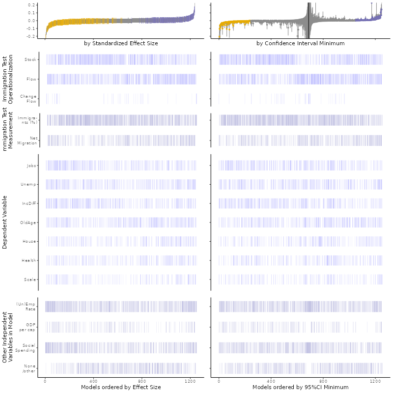

```r
knitr::include_graphics(here::here("results/FigS7.png"))
```

```r
samplabs <- c("1996 &\n2006","2006 &\n2016","1996, 2006\n& 2016","Other")

 g9 <-
ggplot(crispectest) +
  geom_tile(aes(x = count, y = 4, fill = factor(W_96_06)), height = 0.5, width = 0.2) +
  geom_tile(aes(x = count, y = 3, fill = factor(W_96_06_16)), height = 0.5, width = 0.2) +
  geom_tile(aes(x = count, y = 2, fill = factor(W_06_16)), height = 0.5, width = 0.2) +
  geom_tile(aes(x = count, y = 1, fill = factor(W_Other)), height = 0.5, width = 0.2) +
  scale_y_continuous(breaks = c(4,3,2,1), labels=samplabs) +
  scale_fill_manual(values = c("NA","blue")) +
    theme_classic() +
  ylab("Survey Waves in Sample") +
  theme(
    axis.title.x = element_blank(),
    legend.position = "none",
    axis.line.x = element_blank(),
    axis.ticks.x = element_blank(),
    axis.text.x = element_blank(),
  )

 g9ci <-
ggplot(crispectest) +
  geom_tile(aes(x = count2, y = 4, fill = factor(W_96_06)), height = 0.5, width = 0.2) +
  geom_tile(aes(x = count, y = 3, fill = factor(W_96_06_16)), height = 0.5, width = 0.2) +
  geom_tile(aes(x = count2, y = 2, fill = factor(W_06_16)), height = 0.5, width = 0.2) +
  geom_tile(aes(x = count2, y = 1, fill = factor(W_Other)), height = 0.5, width = 0.2) +
  scale_y_continuous(breaks = c(4,3,2,1), labels=samplabs) +
  scale_fill_manual(values = c("NA","blue")) +
    theme_classic() +
  ylab("Survey Waves in Sample") +
  theme(
    axis.title.x = element_blank(),
    axis.title.y = element_blank(),
    legend.position = "none",
    axis.line.x = element_blank(),
    axis.ticks.x = element_blank(),
    axis.text.x = element_blank(),
    axis.text.y = element_blank(),
  )
```

```r
clabs <- c("Rich 13"," CEE/East\nEurope","All\nAvailable","Other")

g10 <-
ggplot(crispectest) +
  geom_tile(aes(x = count, y = 4, fill = factor(C_13)), height = 0.5, width = 0.2) +
  geom_tile(aes(x = count, y = 3, fill = factor(C_CEE)), height = 0.5, width = 0.2) +
  geom_tile(aes(x = count, y = 2, fill = factor(C_All)), height = 0.5, width = 0.2) +
  geom_tile(aes(x = count, y = 1, fill = factor(C_Other)), height = 0.5, width = 0.2) +
  scale_y_continuous(breaks = c(4,3,2,1), labels=clabs) +
  scale_fill_manual(values = c("NA","darkblue")) +
    theme_classic() +
  ylab("Countries in Sample") +
  theme(
    axis.title.x = element_blank(),
    legend.position = "none",
    axis.line.x = element_blank(),
    axis.ticks.x = element_blank(),
    axis.text.x = element_blank(),
  )

g10ci <-
ggplot(crispectest) +
  geom_tile(aes(x = count2, y = 4, fill = factor(C_13)), height = 0.5, width = 0.2) +
  geom_tile(aes(x = count2, y = 3, fill = factor(C_CEE)), height = 0.5, width = 0.2) +
  geom_tile(aes(x = count2, y = 2, fill = factor(C_All)), height = 0.5, width = 0.2) +
  geom_tile(aes(x = count2, y = 1, fill = factor(C_Other)), height = 0.5, width = 0.2) +
  scale_y_continuous(breaks = c(4,3,2,1), labels=clabs) +
  scale_fill_manual(values = c("NA","darkblue")) +
    theme_classic() +
  ylab("Countries in Sample") +
  theme(
    axis.title.x = element_blank(),
    axis.title.y = element_blank(),
    legend.position = "none",
    axis.line.x = element_blank(),
    axis.ticks.x = element_blank(),
    axis.text.x = element_blank(),
    axis.text.y = element_blank(),
  )
```

```r
estlabs <- c("OLS","Logit"," ML/GLM","Ordered\nlogit","Bayes")

g11 <-
ggplot(crispectest) +
  geom_tile(aes(x = count, y = 5, fill = factor(Est_ols)), height = 0.5, width = 0.2) +
  geom_tile(aes(x = count, y = 4, fill = factor(Est_logit)), height = 0.5, width = 0.2) +
  geom_tile(aes(x = count, y = 3, fill = factor(Est_mlglm)), height = 0.5, width = 0.2) +
  geom_tile(aes(x = count, y = 2, fill = factor(Est_ologit)), height = 0.5, width = 0.2) +
  geom_tile(aes(x = count, y = 1, fill = factor(Est_bayes)), height = 0.5, width = 0.2) +
  scale_y_continuous(breaks = c(5,4,3,2,1), labels=estlabs) +
  scale_fill_manual(values = c("NA","blue")) +
    theme_classic() +
  ylab("Estimation Method") +
  xlab("Models ordered by Effect Size") +
  theme(
    #axis.title.x = element_blank(),
    legend.position = "none",
    axis.line.x = element_blank(),
    axis.ticks.x = element_blank(),
    axis.text.x = element_blank(),
  )

g11ci <-
ggplot(crispectest) +
  geom_tile(aes(x = count2, y = 5, fill = factor(Est_ols)), height = 0.5, width = 0.2) +
  geom_tile(aes(x = count2, y = 4, fill = factor(Est_logit)), height = 0.5, width = 0.2) +
  geom_tile(aes(x = count2, y = 3, fill = factor(Est_mlglm)), height = 0.5, width = 0.2) +
  geom_tile(aes(x = count2, y = 2, fill = factor(Est_ologit)), height = 0.5, width = 0.2) +
  geom_tile(aes(x = count2, y = 1, fill = factor(Est_bayes)), height = 0.5, width = 0.2) +
  scale_y_continuous(breaks = c(5,4,3,2,1), labels=estlabs) +
  scale_fill_manual(values = c("NA","blue")) +
    theme_classic() +
  ylab("Estimation Method") +
  xlab("Models ordered by 95%CI Minimum") +
  theme(
    axis.title.y = element_blank(),
    legend.position = "none",
    axis.line.x = element_blank(),
    axis.ticks.x = element_blank(),
    axis.text.x = element_blank(),
    axis.text.y = element_blank(),
  )
```

```r
agg_png(filename = here::here("results/FigS8.png"), height = 600, width = 800, res = 72)
ggarrange(g1a, g2a, g9, g9ci, g10, g10ci, g11, g11ci, nrow = 4, ncol = 2, heights = c(0.6,1,1,1.2), widths = c(1,0.9))
dev.off()
```

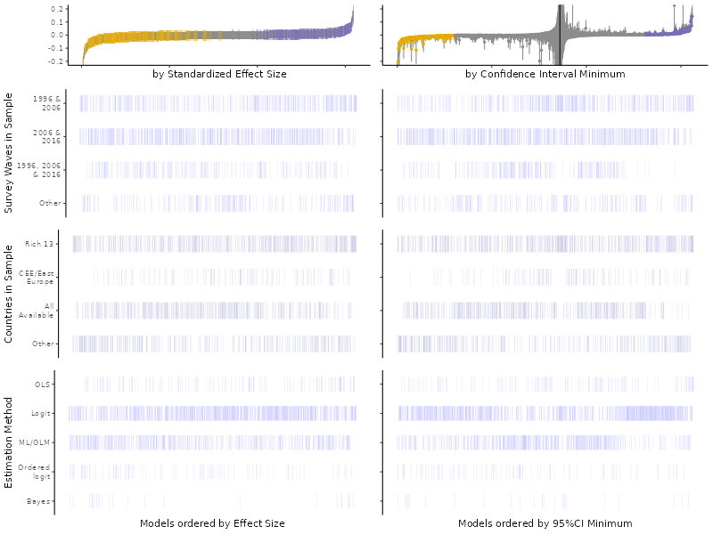

```r
knitr::include_graphics(here::here("results/FigS8.png"))
```

### Fig S9. Team-Level Supplementary Plot

```r
cri_team <- cri_team %>%
  mutate(subj_concl = factor(Hresult, levels = c("Reject","No test","Support")),
         pct_negpos = ifelse(subj_concl == "Reject", AME_neg_p05,
                             ifelse(subj_concl == "No test", AME_ns_p05, AME_sup_p05)))

# order rows to make counter (by negpos)
cri_team <- cri_team[order(cri_team$subj_concl, cri_team$pct_negpos),]
cri_team$count <- 1:nrow(cri_team)

# alternative counter (by average effect size within conclusions)
cri_team <- cri_team[order(cri_team$subj_concl, cri_team$AME_Z),]
cri_team$count2 <- 1:nrow(cri_team)

# create trimmed AME for plotting
cri_team <- cri_team %>%
  mutate(AME_Zt = ifelse(AME_Z < -0.03, -0.03, ifelse(AME_Z > 0.02, 0.02, AME_Z)))

cri_team <- cri_team %>%
  mutate(belief_ipredm = scale(ifelse(is.na(belief_ipred), mean(belief_ipred, na.rm=T), belief_ipred)),
         pro_immigrantm = scale(ifelse(is.na(pro_immigrant), mean(pro_immigrant, na.rm=T), pro_immigrant)),
         topic_ipredm = scale(ifelse(is.na(topic_ipred), mean(topic_ipred, na.rm=T), topic_ipred)),
         stats_ipredm = scale(ifelse(is.na(stats_ipred), mean(stats_ipred, na.rm=T), stats_ipred)),
         total_scorem = scale(ifelse(is.na(total_score), mean(total_score, na.rm=T), total_score)),
         percentpos = scale(pos_test_pct_p05),
         belief_ipredm = ifelse(belief_ipredm > 2, 2, ifelse(belief_ipredm < -2, -2, belief_ipredm)),
         pro_immigrantm = ifelse(pro_immigrantm > 2, 2, ifelse(pro_immigrantm < -2, -2, pro_immigrantm)),
         topic_ipredm = ifelse(topic_ipredm > 2, 2, ifelse(topic_ipredm < -2, -2, topic_ipredm)),
         stats_ipredm = ifelse(stats_ipredm > 2, 2, ifelse(stats_ipredm < -2, -2, belief_ipredm)),
         total_scorem = ifelse(total_scorem > 2, 2, ifelse(total_scorem < -2, -2, total_scorem)),
         percentpos = ifelse(percentpos > 2, 2, ifelse(percentpos < -2, -2, percentpos)))

labs_y <- c("Model Score","Stats-Skill","Topic\nKnowledge","Pro Immigrant","Belief Hyp. True")

labs_y_new <- c("Model Score","Stats-Skill","Topic\nKnowledge","Pro Immigrant","Belief Hyp. True", "% Positive\nTest Results")
```

#### Figure S9

```r
g5a_new <-
  ggplot(cri_team) +
  geom_point(aes(x = count2, y = AME_Zt, color = subj_concl), shape = 18, size = 4) +   scale_color_manual(values = c("#7570B3", "grey55", "#E6AB02"), labels = c("Rejected","Not testable","Supported")) +
  labs(color = "Conclusion\nHypothesis is:", x = "Team Conclusions", y = "Average Effect Size\nof Team's Test Models") +
  theme_classic() +
  theme(
    plot.margin=unit(c(0.2,0.2,0.2,1.05),"cm"),
    axis.title.y = element_text(size = 12),
    axis.title.x = element_text(size = 12),
    axis.text.x = element_blank(),
  )

g5b_new <- ggplot(cri_team) +
  geom_tile(aes(x = count2, y = 6, fill = percentpos), height = 0.5) +
  geom_tile(aes(x = count2, y = 5, fill = belief_ipredm), height = 0.5) +
  geom_tile(aes(x = count2, y = 4, fill = pro_immigrantm), height = 0.5) +
  geom_tile(aes(x = count2, y = 3, fill = topic_ipredm), height = 0.5) +
  geom_tile(aes(x = count2, y = 2, fill = stats_ipredm), height = 0.5) +
  geom_tile(aes(x = count2, y = 1, fill = total_scorem), height = 0.5) +
  scale_y_continuous(breaks = c(1,2,3,4,5,6), labels=labs_y_new) +
    theme_classic() +
  labs(fill = "Standardized\nScore") +
  theme(
    #legend.position = "none",
    axis.title.y = element_blank(),
    axis.title.x = element_blank(),
    axis.text.x = element_blank(),
    plot.margin=unit(c(0.2,0.3,0.2,0.5),"cm")
  )
agg_png(filename = here::here("results/FigS9.png"), res = 144, height = 900, width = 1200)
ggarrange(g5a_new,g5b_new,ncol = 1, heights = c(1,1.2))
dev.off()
```

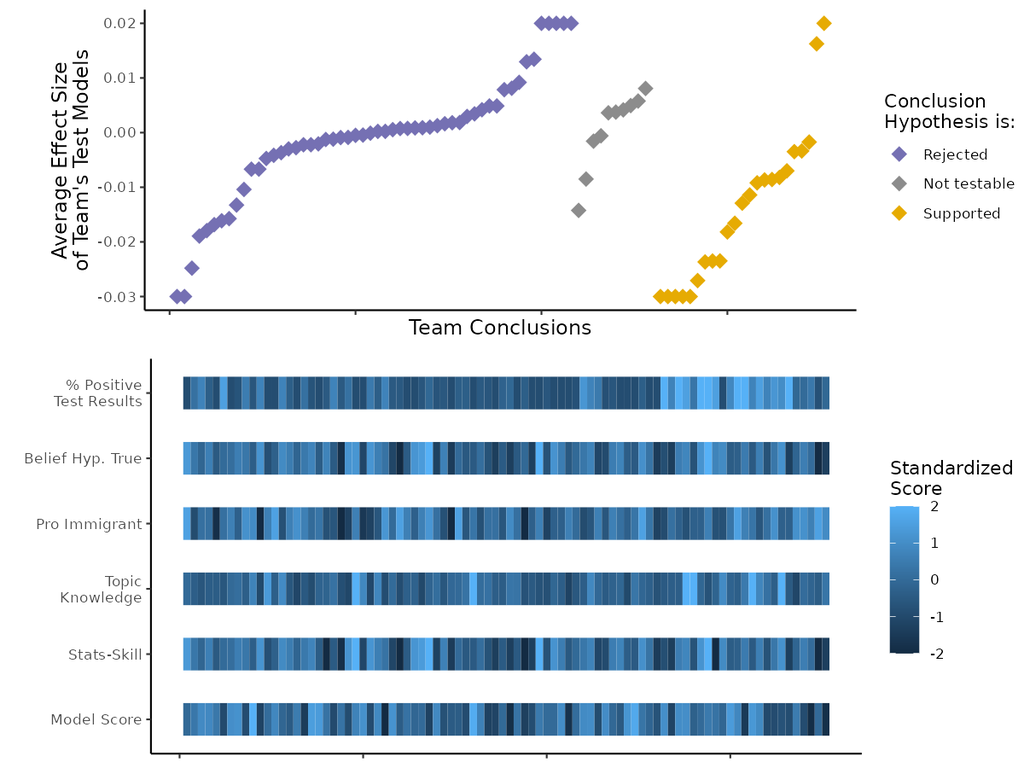

```r
knitr::include_graphics(here::here("results/FigS9.png"))
```

#### Note for FigS9

We find that 0.148 percent of teams had a majority of positive test results (a negative effect of immigration at p<0.05) and 0.068 percent had a majority negative.

```r
write.csv(crispectest, file = here::here("results/crispectest.csv"))
```

## Colophon

This file is part of https://github.com/nbreznau/CRI, the reproduction materials for [*Observing Many Researchers using the Same Data and Hypothesis Reveals a Hidden Universe of Uncertainty*](https://doi.org/10.31222/osf.io/cd5j9).